# Rethinking: Chapter 4 EoC Questions

# Hard Questions

### 4H1 The weights listed below were recorded in the !Kung census, but heights were not recorded for these individuals. Provide predicted heights and 89% intervals for each of these individuals. That is, fill in the table below, using model-based predictions.

| Individual | weight | expected height | 89% interval |
| --- | --- | --- | --- |
| 1 | 46.95 |  |  |
| 2 | 43.72 |  |  |
| 3 | 64.78 |  |  |
| 4 | 32.59 |  |  |
| 5 | 54.63 |  |  |

Assuming these are all above 18 years of age, and using the model m4.3 created within the chapter.

```r
data("Howell1")
dh <- Howell1
dh2 <- dh[dh$age > 18, ]

xbar <- mean(dh2$weight)

m4.3 <- quap(
    alist(
        height ~ dnorm( mu , sigma ) ,
        mu <- a + b*( weight - xbar ) ,
        a ~ dnorm( 178 , 20 ) ,
        b ~ dlnorm( 0 , 1 ) ,
        sigma ~ dunif( 0 , 50 )
    ) ,
    data=dh2
)

weights <- c(46.95, 43.72, 64.78, 32.59, 54.63)
mu_pred <- link(m4.3, list(weight = weights))

mu_pred_mean <- apply(mu_pred, 2, mean)
mu_pred_PI <- apply(mu_pred, 2, PI, 0.89)

data.frame(
    weight = weights,
    expected_height = mu_pred_mean,
    `lower bound 89%` = mu_pred_PI[1,],
    `upper bound 89%` = mu_pred_PI[2,]
)
```

```
##   weight expected_height lower.bound.89. upper.bound.89.
## 1  46.95        156.3791        155.9155        156.8164
## 2  43.72        153.4550        152.9917        153.9021
## 3  64.78        172.5204        171.1058        173.8649
## 4  32.59        143.3791        142.4240        144.3008
## 5  54.63        163.3317        162.5415        164.0802
```

### 4H2 Select out all the rows in the Howell1 data with ages below 18 years of age. If you do it right, you should end up with a new data frame with 192 rows in it.

```r
dh3 <- dh[dh$age < 18, ]
nrow(dh3)
```

```
## [1] 192
```

#### (a) Fit a linear regression to these data, using quap. Present and interpret the estimates. For every 10 units of increase in weight, how much taller does the model predict a child gets?

Assuming the following model:

```r
mod <- quap(
    alist(
        height ~ dnorm(mu, sigma),
        mu <- a + b * weight,
        a ~ dnorm(135, 40),
        b ~ dlnorm(0, 1),
        sigma ~ dunif(0, 50)
    ),
    data = dh3
)

precis(mod)
```

```
##            mean         sd      5.5%     94.5%
## a     58.387317 1.39685732 56.154869 60.619764
## b      2.712542 0.06828725  2.603405  2.821678
## sigma  8.437428 0.43060295  7.749242  9.125615
```

#### (b) Plot the raw data, with height on the vertical axis and weight on the horizontal axis. Superimpose the MAP regression line and 89% interval for the mean. Also superimpose the 89% interval for predicted heights.

```r
range(dh3$weight)
```

```
## [1]  4.252425 44.735511
```

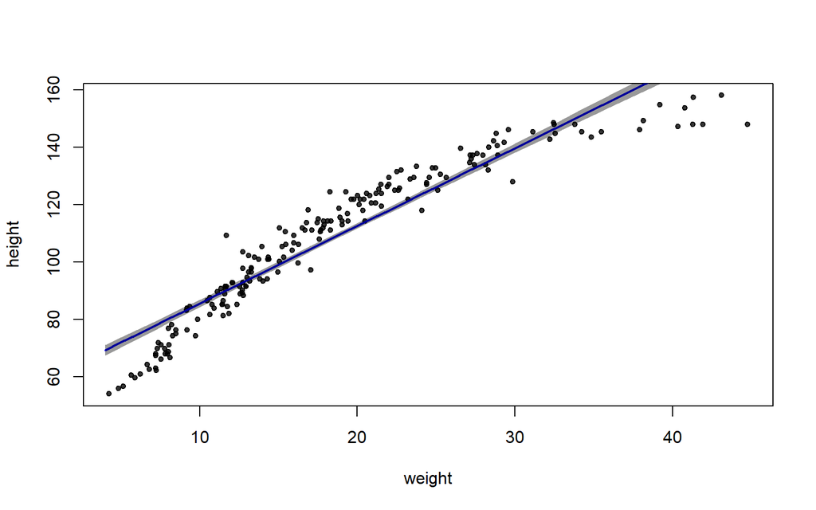

```r
weight.seq <- seq(4, 45, by = 1)

sample_mu <- link(mod, list(weight = weight.seq))
mu.mean <- apply(sample_mu, 2, mean)
mu.PI <- apply(sample_mu, 2, PI, 0.89)

sim_heights <- sim(mod, list(weight = weight.seq))
simh <- apply(sim_heights, 2, PI, 0.89)

plot(height ~ weight, data = dh3, col = col.alpha('black', 0.8), pch = 20)
lines(weight.seq, mu.mean, lwd = 2, col = 'blue')
shade(mu.PI, weight.seq, col = col.alpha('black', 0.4))
shade(simh, weight.seq, col = col.alpha('blue', 0.1))
```

#### c) What aspects of the model fit concern you? Describe the kinds of assumptions you would change, if any, to improve the model. You don’t have to write any new code. Just explain what the model appears to be doing a bad job of, and what you hypothesize would be a better model.

The model assumes a linear relationship between weight and height, which from the graph above is clearly not the case. The height increases at a much higher rate for younger children compared to older kids, which can be seen in the graph as the height begins to plateau towards the end. A better fit would involve some non-linear relationship, using polynomial terms or splines with 3-4 knots.

### 4H3 Suppose a colleague of yours, who works on allometry, glances at the practice problems just above. Your colleague exclaims, “That’s silly. Everyone knows that it’s only the logarithm of body weight that scales with height!” Let’s take your colleague’s advice and see what happens.

#### (a)Model the relationship between height (cm) and the natural logarithm of weight (log-kg). Use the entire Howell1 data frame, all 544 rows, adults and non-adults. Can you interpret the resulting estimates?

```r
mod2 <- quap(
    alist(
        height ~ dnorm(mu, sigma),
        mu <- a + b * log(weight),
        a ~ dnorm(135, 40),
        b ~ dlnorm(0, 1),
        sigma ~ dunif(0, 50)
    ),
    data = dh
)

precis(mod2)
```

```
##             mean        sd       5.5%      94.5%
## a     -23.594556 1.3347738 -25.727782 -21.461330
## b      47.021187 0.3824533  46.409953  47.632421
## sigma   5.134845 0.1556812   4.886036   5.383654
```

Interpretation:

- $\alpha$ - average height when log weight is zero (which would imply weight = 1kg) is -23.59.
- $\beta$ - height increases by 47.02 cm when log weight increases by one, or when weight increases 2.72 times (we are using natural log here)
- $\sigma$ - sd of heights is 5.13 cm.

####(b) Begin with this plot: plot( height ~ weight , data=Howell1 ). Then use samples from the quadratic approximate posterior of the model in (a) to superimpose on the plot: (1) the predicted mean height as a function of weight, (2) the 97% interval for the mean, and (3) the 97% interval for predicted heights.

```r
range(dh$weight)
```

```
## [1]  4.252425 62.992589
```

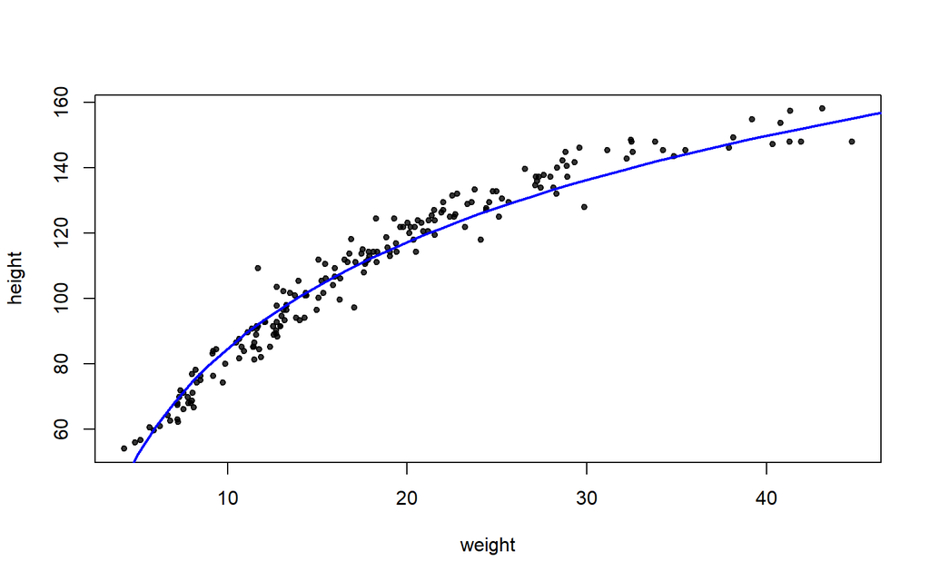

```r
weight.seq <- seq(4, 63, by = 1)

sample_mu <- link(mod2, list(weight = weight.seq))
mu.mean <- apply(sample_mu, 2, mean)
mu.PI <- apply(sample_mu, 2, PI, 0.89)

sim_heights <- sim(mod2, list(weight = weight.seq))
simh <- apply(sim_heights, 2, PI, 0.89)

plot(height ~ weight, data = dh3, col = col.alpha('black', 0.8), pch = 20)
lines(weight.seq, mu.mean, lwd = 2, col = 'blue')
shade(mu.PI, weight.seq, col = col.alpha('black', 0.4))
shade(simh, weight.seq, col = col.alpha('blue', 0.1))
```

A much better fit!

### 4H4 Plot the prior predictive distribution for the parabolic polynomial regression model in the chapter. You can modify the code that plots the linear regression prior predictive distribution. Can you modify the prior distributions of α, β1, and β2 so that the prior predictions stay within the biologically reasonable outcome space? That is to say: Do not try to fit the data by hand. But do try to keep the curves consistent with what you know about height and weight, before seeing these exact data.

Let us first write down the model equation:

$$
$$\begin{align}
height &\sim Normal(\mu, \sigma) \\
\mu &= \alpha + \beta_1 weight_s + \beta_2 weight_s^2 \\
\alpha &\sim Normal(178, 20) \\
\beta_1 &\sim \operatorname{Log-Normal(0, 1)} \\
\beta_2 &\sim Normal(0, 1) \\
\sigma &\sim Uniform(0, 50)
\end{align}$$

```r
dh$weight_s <- ( dh$weight - mean(dh$weight) ) / sd(dh$weight)
dh$weight_s2 <- dh$weight_s^2

plot_prior_poly <- function(a, b1, b2, N = 100){
    plot( NULL , xlim=range(dh$weight_s) , ylim=c(-100,400) , xlab="weight" , ylab="height")
    abline( h=0 , lty=2 )
    abline( h=272 , lty=1 , lwd=0.5 )
    mtext( "b1 ~ dlnorm(0,1); b2 ~ dnorm(0, 1)" )

    for ( i in 1:N )
        curve( a[i] + b1[i]*x + b2[i]*(x^2) ,
               from = min(dh$weight_s) , to = max(dh$weight_s) ,
               add = TRUE , col=col.alpha("black", 0.2) )
}
```

What do we know about human heights?

- kids grow fast, as we grow old, we don’t grow taller anymore
- biological limits
- heights lie in the range of 0 to 272, avg (taking into account kids would be in the range of 120?)

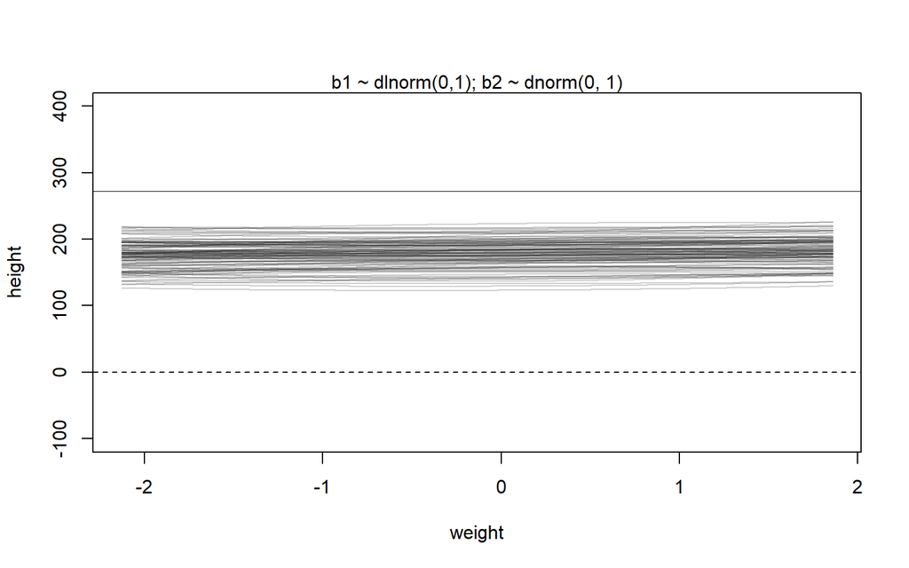

```r
# original priors
N <- 100
plot_prior_poly(
    a = rnorm(N, 178, 20),
    b1 = rlnorm(N, 0, 1),
    b2 = rnorm(N, 0, 1),
    N
)
```

These are mostly straight lines, no curvature to account for the change in growth rate.

[figure not shown]

```r
plot_prior_poly(
    a = rnorm(N, 150, 20),
    b1 = rlnorm(N, 3, 0.3),
    b2 = rnorm(N, -10, 2),
    N
)
```

This seems to be a better prior that takes into account the curvature present in the data.

### 4H5 Return to data(cherry_blossoms) and model the association between blossom date (doy) and March temperature (temp). Note that there are many missing values in both variables. You may consider a linear model, a polynomial, or a spline on temperature. How well does temperature trend predict the blossom trend?

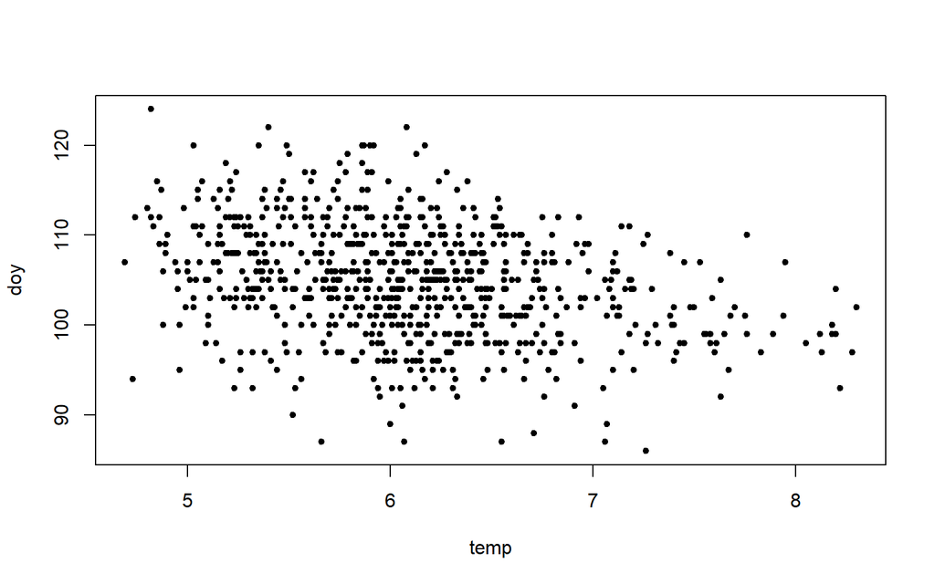

```r
data("cherry_blossoms")
ch <- cherry_blossoms[complete.cases(cherry_blossoms),]
plot(doy ~ temp, data = ch, pch = 20)
```

We can have the following models - Linear, polynomial with degree 3 and splines model:

$$
$$\begin{align}
D_i &\sim Normal(\mu_i , \sigma) \\
\mu &= \alpha + \beta \ t_i \\
\alpha &= Normal(100, 10) \\
\beta &= Normal(0, 10) \\
\sigma &= Uniform(0, 50)
\end{align}$$
$$

```r
mch_lin <- quap(
    alist(
        doy ~ dnorm(mu, sigma),
        mu <- a + b * temp,
        a ~ dnorm(100, 10),
        b ~ dnorm(0, 10),
        sigma ~ dunif(0, 50)
    ),
    data = ch
)
precis(mch_lin)
```

```
##             mean        sd       5.5%      94.5%
## a     122.370906 1.8601930 119.397958 125.343854
## b      -2.862113 0.3031032  -3.346530  -2.377695
## sigma   5.910713 0.1490177   5.672554   6.148872
```

Let’s plot the posterior prediction for this:

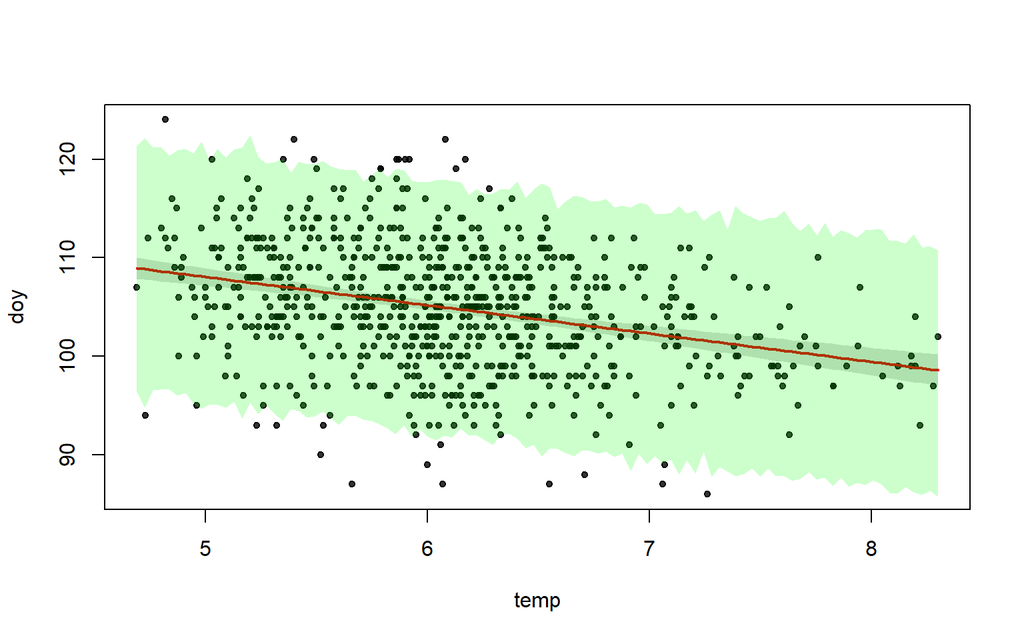

```r
t_seq <- seq(min(ch$temp), max(ch$temp), length.out = 100)

mu_lin <- link(mch_lin, data = list(temp = t_seq))
mu_lin_mean <- apply(mu_lin, 2, mean)
mu_lin_PI <- apply(mu_lin, 2, PI, 0.97)

dsim <- apply(sim(mch_lin, list(temp = t_seq)), 2, PI, 0.97)


plot(doy ~ temp, data = ch, pch = 20, col = col.alpha('black', 0.8))
lines(t_seq, mu_lin_mean, lwd = 2, col = 'red')
shade(mu_lin_PI, t_seq)
shade(dsim, t_seq, col = col.alpha('green', 0.2) )
```

Seems to be a good enough fit.

Let’s try a polynomial next.

```r
ch2 <- ch
ch2$temp_s <- (ch2$temp - mean(ch2$temp)) / sd(ch2$temp)
ch2$temp_s2 <- ch2$temp_s^2
ch2$temp_s3 <- ch2$temp_s^3

mch_poly <- quap(
    alist(
        doy ~ dnorm(mu, sigma),
        mu <- a + b1 * temp_s + b2 * temp_s2 + b3 * temp_s3,
        a ~ dnorm(100, 10),
        b1 ~ dnorm(0, 10),
        b2 ~ dnorm(0, 10),
        b3 ~ dnorm(0, 10),
        sigma ~ dunif(0, 50)
    ),
    data = ch2
)
precis(mch_poly)
```

```
##               mean        sd        5.5%       94.5%
## a     104.95356995 0.2709141 104.5205969 105.3865430
## b1     -2.20731179 0.3665419  -2.7931165  -1.6215071
## b2     -0.06919811 0.2102626  -0.4052383   0.2668421
## b3      0.06005884 0.1111464  -0.1175745   0.2376922
## sigma   5.90883848 0.1489359   5.6708102   6.1468668
```

Let’s see the posterior distribution for this:

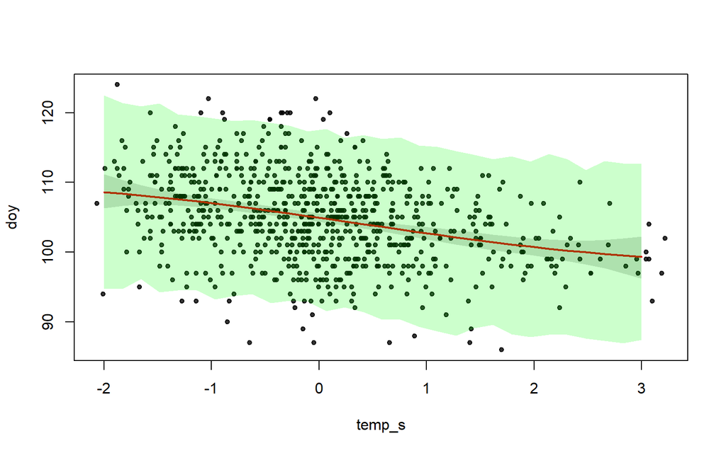

```r
t_seq <- seq(-2, 3, length.out = 30)

pred_dat <- list( temp_s = t_seq, temp_s2 = t_seq^2, temp_s3 = t_seq^3)

mu_poly <- link(mch_poly, data = pred_dat)
mu_poly_mean <- apply(mu_poly, 2, mean)
mu_poly_PI <- apply(mu_poly, 2, PI, 0.97)

dsim <- apply(sim(mch_poly, pred_dat), 2, PI, 0.97)


plot(doy ~ temp_s, data = ch2, pch = 20, col = col.alpha('black', 0.8))
lines(t_seq, mu_poly_mean, lwd = 2, col = 'red')
shade(mu_poly_PI, t_seq)
shade(dsim, t_seq, col = col.alpha('green', 0.2) )
```

This is mostly a linear fit with just some curvautre at the ends. We can also look at the output of `precis` to confirm that the mean values for b2 and b3 are almost zero.

### 4H6 Simulate the prior predictive distribution for the cherry blossom spline in the chapter. Adjust the prior on the weights and observe what happens. What do you think the prior on the weights is doing?

```r
data("cherry_blossoms")
d <- cherry_blossoms

d2 <- d[ complete.cases(d$doy) , ] # complete cases on doy

# create basis splintes with 15 knots
num_knots <- 15
knot_list <- quantile( d2$year , probs=seq(0,1,length.out=num_knots) )

B <- bs(d2$year,
        knots=knot_list[-c(1,num_knots)] ,
        degree=3 , intercept=TRUE )

alist( D ~ dnorm( mu , sigma ) ,
       mu <- a + B %*% w ,
       a ~ dnorm(100,10),
       w ~ dnorm(0,10),
       sigma ~ dexp(1)
)
```

```
## [[1]]
## D ~ dnorm(mu, sigma)
##
## [[2]]
## mu <- a + B %*% w
##
## [[3]]
## a ~ dnorm(100, 10)
##
## [[4]]
## w ~ dnorm(0, 10)
##
## [[5]]
## sigma ~ dexp(1)
```

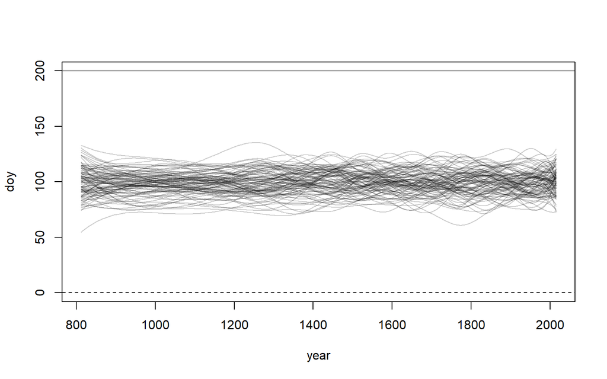

```r
plot_prior_spline <- function(a, w, N){
    plot( NULL , xlim = range(d2$year) , ylim=c(0, 200) , xlab="year" , ylab="doy")
    abline( h = 0 , lty=2 )             # earliest day in year
    abline( h = 200 , lty=1 , lwd=0.5 ) # max day in year

    for ( i in 1:N ) {
        y <- a[i] + B %*% w[i,]
        lines(d2$year, y, col = col.alpha('black', 0.2))
    }

}

N <- 100

# Original Priors
plot_prior_spline(
    a = rnorm(N, 100, 10),
    w = matrix(rnorm(N*ncol(B), 0, 10), nrow = N, ncol = ncol(B)),
    N
)
```

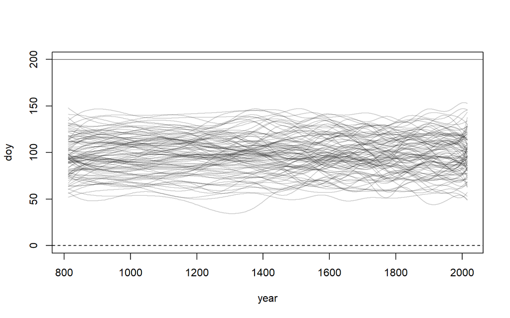

```r
# Other Priors
plot_prior_spline(
    a = rnorm(N, 100, 20),
    w = matrix(rnorm(N*ncol(B), 0, 10), nrow = N, ncol = ncol(B)),
    N
)
```

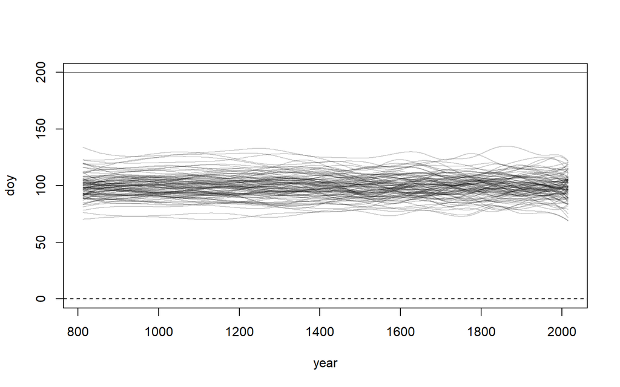

```r
plot_prior_spline(
    a = rnorm(N, 100, 10),
    w = matrix(rnorm(N*ncol(B), 0, 5), nrow = N, ncol = ncol(B)),
    N
)
```

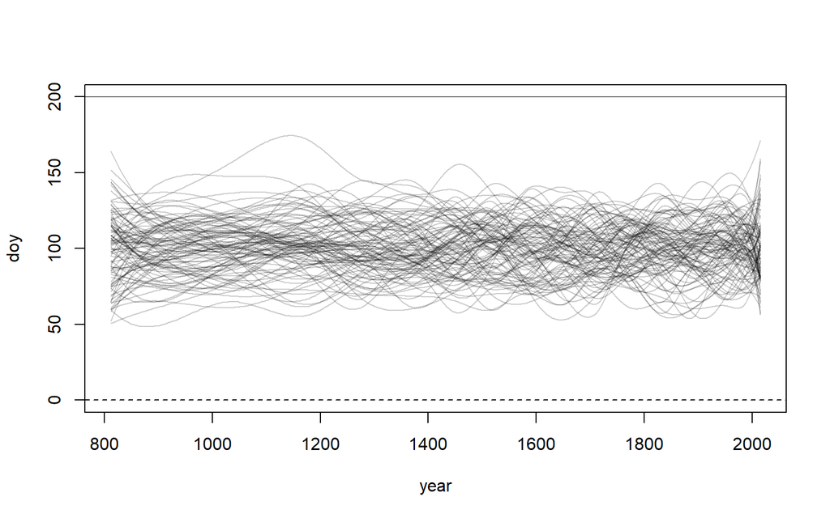

```r
plot_prior_spline(
    a = rnorm(N, 100, 10),
    w = matrix(rnorm(N*ncol(B), 0, 20), nrow = N, ncol = ncol(B)),
    N
)
```

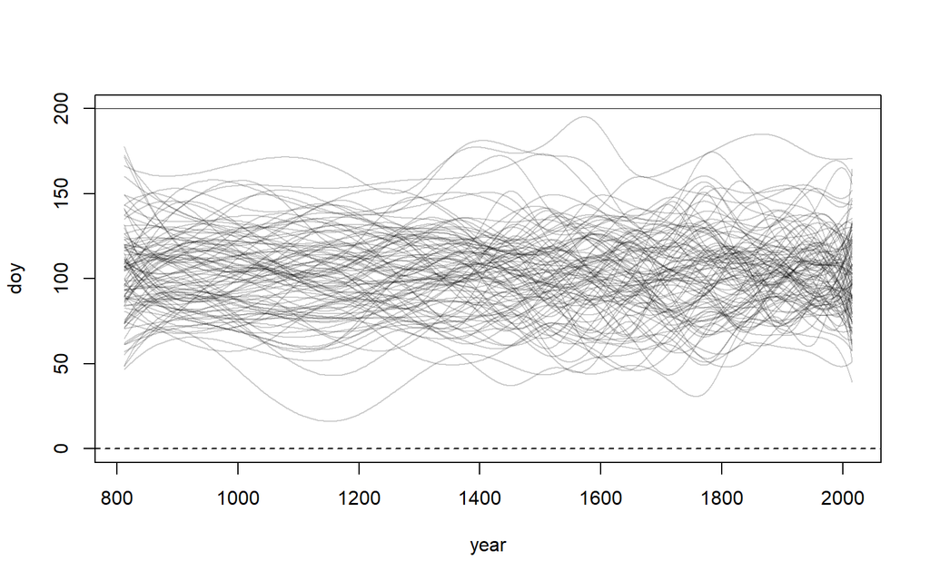

```r
plot_prior_spline(
    a = rnorm(N, 100, 20),
    w = matrix(rnorm(N*ncol(B), 0, 20), nrow = N, ncol = ncol(B)),
    N
)
```

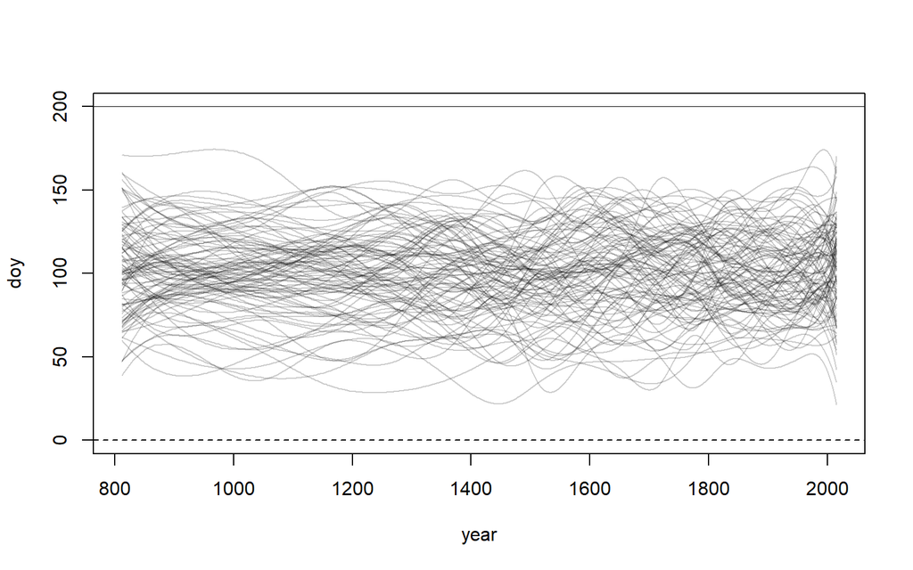

```r
plot_prior_spline(
    a = rnorm(N, 100, 20),
    w = matrix(rnorm(N*ncol(B), 3, 20), nrow = N, ncol = ncol(B)),
    N
)
```

The prior on the weights seems to be affect how much the model can localise (how squiggly can the lines get).

### 4H8 (there is no 4H7) The cherry blossom spline in the chapter used an intercept α, but technically it doesn’t require one. The first basis functions could substitute for the intercept. Try refitting the cherry blossom spline without the intercept. What else about the model do you need to change to make this work?

```r
data("cherry_blossoms")
d <- cherry_blossoms

d2 <- d[ complete.cases(d$doy) , ] # complete cases on doy

# create basis splintes with 15 knots
num_knots <- 15
knot_list <- quantile( d2$year , probs=seq(0,1,length.out=num_knots) )
B <- bs(d2$year,
        knots=knot_list[-c(1,num_knots)] ,
        degree=3 , intercept=TRUE )

m4.8 <- quap(
    alist( D ~ dnorm( mu , sigma ) ,
           mu <- B %*% w ,
           # a ~ dnorm(100,10),
           w ~ dnorm(0,10),
           sigma ~ dexp(1)
    ),
    data = list( D = d2$doy , B = B ) ,
    start = list( w = rep( 0 , ncol(B) ) ) )

# can check the posterior means for all params
precis(m4.8, depth = 2)
```

```
##             mean        sd       5.5%      94.5%
## w[1]   92.838731 3.2201626  87.692290  97.985173
## w[2]  102.760409 3.0854478  97.829267 107.691550
## w[3]  100.428973 2.7543625  96.026969 104.830976
## w[4]  108.337582 1.6439729 105.710196 110.964968
## w[5]  101.558858 1.6760828  98.880154 104.237562
## w[6]  106.968261 1.7385933 104.189653 109.746869
## w[7]   97.554281 1.5259420  95.115531  99.993031
## w[8]  110.637344 1.5320294 108.188866 113.085823
## w[9]  101.677640 1.6790261  98.994232 104.361048
## w[10] 105.758620 1.7276596 102.997486 108.519754
## w[11] 107.369283 1.6970097 104.657134 110.081433
## w[12] 102.668148 1.6532521 100.025932 105.310364
## w[13] 108.149485 1.6931479 105.443508 110.855462
## w[14] 103.769605 1.8668756 100.785978 106.753233
## w[15] 101.303865 2.3410846  97.562360 105.045371
## w[16]  95.977783 2.4387956  92.080117  99.875450
## w[17]  92.126400 2.2979856  88.453776  95.799025
## sigma   5.946086 0.1488284   5.708229   6.183942
```

Earlier, all the ‘w’ terms were around 0, now they are in the range of 100. The intercept was catching the average first day for blooming of cherry blossoms, now this part is captured by the all the ‘w’.

Let us next look at the posterior distribution.

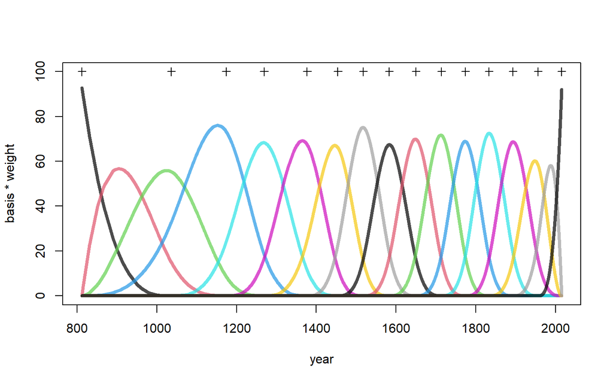

```r
# First, just drawing the splines times the weight
post <- extract.samples( m4.8 )
w <- apply( post$w , 2 , mean )

# Plot the basis functions * weights calculated using quap
plot( NULL , xlim=range(d2$year) , ylim=c(0,100) ,
      xlab="year" , ylab="basis * weight" )

for ( i in 1:ncol(B) )
    lines( d2$year , w[i]*B[,i] , col = col.alpha(i, 0.7), lwd = 4)

points(knot_list, y = rep(100, num_knots), pch = 3)
```

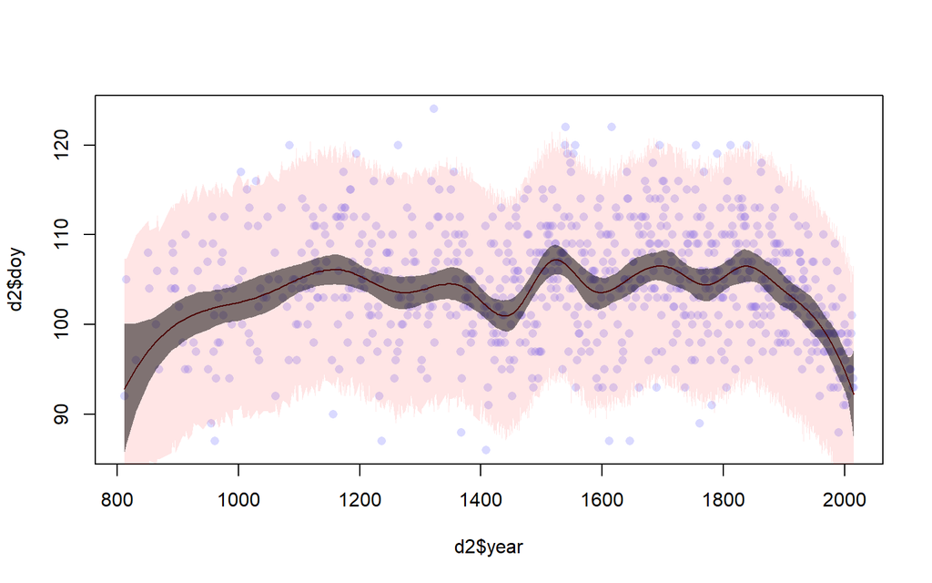

```r
# Now let us look at the posterior distribution
# Posterior interval for mu (97%)
mu <- link( m4.8 )
mu_mean <- apply(mu, 2, mean)
mu_PI <- apply(mu,2,PI,0.97)

doy <- sim(m4.8, list( D = d2$doy , B = B ))
doy_h <- apply(doy, 2, PI, 0.97)

plot( d2$year , d2$doy , col=col.alpha(rangi2,0.3) , pch=16 )
lines(d2$year, mu_mean,  col = 'darkred')
shade(doy_h, d2$year, col = col.alpha('red', 0.1))
shade( mu_PI , d2$year , col=col.alpha("black",0.5) )
```

The model seems to have worked similarly without the intercept.